# R Code for Portfolio Optimization Chapter 5 – Financial Data: Graphs

Daniel P. Palomar (2025). [Portfolio Optimization: Theory and Application.](https://portfoliooptimizationbook.com/) Cambridge University Press.

Last update: April 14, 2025

# Loading packages

The following packages are used in the examples:

```r
# graphs
library(clusterSim)             # graph datasets
library(igraph)                 # for graph related functions
library(dbscan)                 # for kNN computation
library(glasso)                 # GLASSO implementation
library(spectralGraphTopology)  # implementation of many graph learning functions
```

For convenience, we define the following wrapper function (based on the package `igraph`) to plot graphs:

```r
library(igraph)

# define function to plot nice graphs
plot_graph <- function(W, L = NULL, main = "", layout = NULL, clusters, edges = TRUE, labels = FALSE) {
  # if the Laplacian is passed instead, then use it to get W
  if (!is.null(L)) {
    W <- abs(L)
    diag(W) <- 0
  }
  # default layout
  if(is.null(layout)) layout <- layout_with_fr

  # build graph
  graph <- graph_from_adjacency_matrix(W, mode = "undirected", weighted = TRUE)

  # colorify nodes and edges
  V(graph)$cluster <- clusters
  colors <- c("#706FD3", "#FF5252", "#33D9B2")
  V(graph)$color <- colors[clusters]  #V(graph)$color <- clusters
  if (edges)
    E(graph)$color <- apply(as.data.frame(get.edgelist(graph)), 1,
                        function(x) {
                          x <- as.numeric(x)
                          ifelse(V(graph)$cluster[x[1]] == V(graph)$cluster[x[2]],
                                 colors[V(graph)$cluster[x[1]]], "grey")
                        })
  else
    E(graph)$color <- NA

  E(graph)$weight <- E(graph)$weight / max(E(graph)$weight)
  E(graph)$width <- 2*E(graph)$weight

  plot(graph, layout = layout,
       edge.width = E(graph)$width,
       vertex.size = 3,
       vertex.label = NA, #vertex.label.cex = 0.8, vertex.label.dist = 0.7, vertex.label.color = "black",
       edge.curved = 0.25,
       main = main)
}
```

# Learning graphs from similarity measures

First load some toy data:

```r
library(clusterSim)
set.seed(42)
data2moons <- shapes.two.moon(100)
data3circles <- shapes.circles3(100)
```

Let’s define the functions to learn the following graphs (in the form of the adjacency matrix `\bm{W}`) based on similarity measures:

- thresholded distance graph
- Gaussian graph
- thresholded Gaussian graph
- kNN graph
- feature correlation graph
- selftuned Gaussian graph

```r
library(dbscan)

W_thresholded <- function(X, threshold = NULL) {
  # compute Euclidean distance matrix
  euclid_dist <- as.matrix(dist(X, method = "euclidean", diag = FALSE, upper = FALSE))
  # choose threshold automatically if needed
  if (is.null(threshold)) {
    max_dist <- max(euclid_dist)
    min_dist <- min(euclid_dist[euclid_dist != 0])
    threshold <- min_dist + 0.15*(max_dist-min_dist)
  }
  # generate W
  W <- ifelse(euclid_dist <= threshold, 1, 0)
  diag(W) <- 0
  return(W)
}

W_Gaussian <- function(X, sigma2 = 0.1) {
  # compute Euclidean distance matrix
  euclid_dist <- as.matrix(dist(X, method = "euclidean", diag = FALSE, upper = FALSE))
  # choose sigma2 automatically if needed
  if (is.null(sigma2))
    sigma2 <- mean(euclid_dist^2)/10
  # generate W
  W <- exp(-(euclid_dist^2)/(2*sigma2))
  diag(W) <- 0
  return(W)
}

W_thresholded_Gaussian <- function(X, sigma2 = 0.1, threshold = NULL) {
  # compute Euclidean distance matrix
  euclid_dist <- as.matrix(dist(X, method = "euclidean", diag = FALSE, upper = FALSE))
  # choose sigma2 automatically?
  if (is.null(sigma2))
    sigma2 <- mean(euclid_dist^2)/10
  # choose threshold automatically if needed
  if (is.null(threshold)) {
    max_dist <- max(euclid_dist)
    min_dist <- min(euclid_dist[euclid_dist != 0])
    threshold <- min_dist + 0.15*(max_dist-min_dist)
  }
  # generate W
  W <- exp(-(euclid_dist^2)/(2*sigma2))
  W[euclid_dist > threshold] <- 0  # threshold
  diag(W) <- 0
  return(W)
}

W_knn <- function(X, k = NULL) {
  p <- nrow(X)
  # choose k automatically if needed
  if (is.null(k))
    k <- 1 + floor(log2(p))
  # compute the knn distances and so
  knn_nodes <- dbscan::kNN(X, k, sort = FALSE)$id
  # generate W
  W <- matrix(0, p, p)
  for (i in 1:p)
    W[knn_nodes[i, ], i] <- W[i, knn_nodes[i, ]] <- 1
  colnames(W) <- rownames(W) <- rownames(X)
  return(W)
}

W_feature_correlation <- function(X, threshold = 0.5) {
  W <- X %*% t(X)
  W[abs(W) < threshold*mean(diag(W))] <- 0
  diag(W) <- 0
  return(W)
}

W_selftuned_Gaussian <- function(X, k = NULL) {
  p <- nrow(X)
  # choose k automatically if needed
  if (is.null(k))
    k <- floor(1 + log2(p))  #0.5*log2(p)
  # compute Euclidean distance matrix and knn distances
  knn_dist <- dbscan::kNN(X, k, sort = TRUE)$dist[, k]
  euclid_dist2 <- as.matrix(dist(X, method = "euclidean", diag = FALSE, upper = FALSE))^2
  #euclid_dist2 <- diag(1/knn_dist) %*% euclid_dist2 %*% diag(1/knn_dist)
  euclid_dist2 <- t((1/knn_dist) * t((1/knn_dist) * euclid_dist2))
  # generate W
  W <- exp(-euclid_dist2/2)
  diag(W) <- 0
  return(W)
}
```

Graphs learned based on similarity measures for the two-moon dataset:

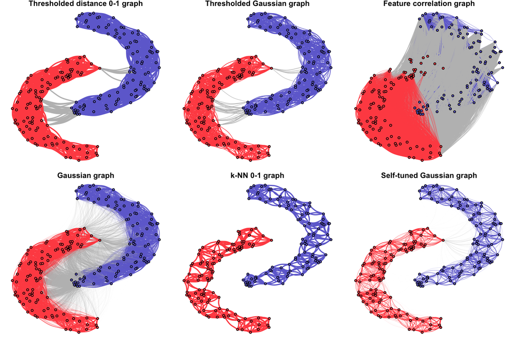

```r
old_par <- par(mfcol = c(2, 3), mar = c(0.6, 0, 0.8, 0))   # b-l-t-r
# thresholded distance graph
plot_graph(W = W_thresholded(data2moons$data),
           layout = data2moons$data, clusters = data2moons$clusters,
           main = "Thresholded distance 0-1 graph")
# Gaussian graph
plot_graph(W = W_Gaussian(data2moons$data),
           layout = data2moons$data, clusters = data2moons$clusters,
           main = "Gaussian graph")
# thresholded Gaussian graph
plot_graph(W = W_thresholded_Gaussian(data2moons$data),
           layout = data2moons$data, clusters = data2moons$clusters,
           main = "Thresholded Gaussian graph")
# k-NN graph
plot_graph(W = W_knn(data2moons$data),
           layout = data2moons$data, clusters = data2moons$clusters,
           main = "k-NN 0-1 graph")
# feature correlation graph
plot_graph(W = W_feature_correlation(data2moons$data),
           layout = data2moons$data, clusters = data2moons$clusters,
           main = "Feature correlation graph")
# self-tuned Gaussian graph
plot_graph(W = W_selftuned_Gaussian(data2moons$data, k = 4),
           layout = data2moons$data, clusters = data2moons$clusters,
           main = "Self-tuned Gaussian graph")
par(old_par)
```

Graphs learned based on similarity measures for the three-circle dataset:

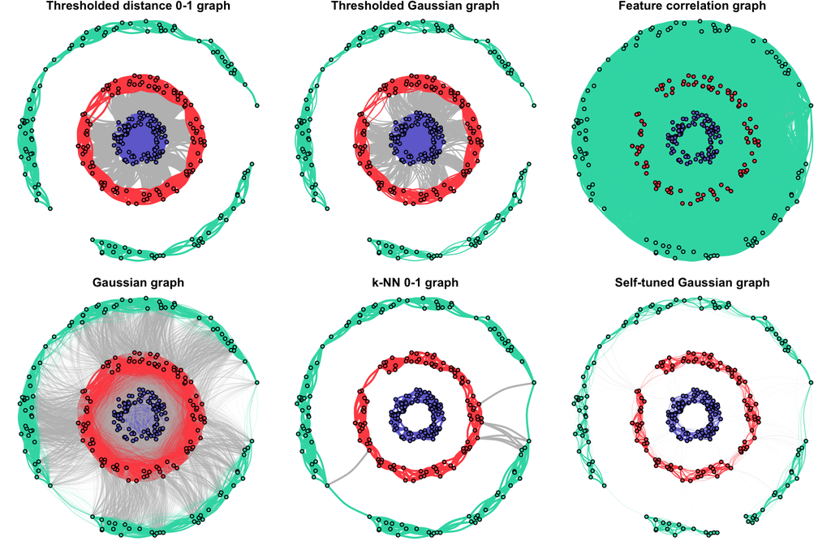

```r
old_par <- par(mfcol = c(2, 3), mar = c(0.6, 0, 0.8, 0))   # b-l-t-r
# thresholded distance graph
plot_graph(W = W_thresholded(data3circles$data),
           layout = data3circles$data, clusters = data3circles$clusters,
           main = "Thresholded distance 0-1 graph")
# Gaussian graph
plot_graph(W = W_Gaussian(data3circles$data),
           layout = data3circles$data, clusters = data3circles$clusters,
           main = "Gaussian graph")
# thresholded Gaussian graph
plot_graph(W = W_thresholded_Gaussian(data3circles$data),
           layout = data3circles$data, clusters = data3circles$clusters,
           main = "Thresholded Gaussian graph")
# k-NN graph
plot_graph(W = W_knn(data3circles$data),
           layout = data3circles$data, clusters = data3circles$clusters,
           main = "k-NN 0-1 graph")
# feature correlation graph
plot_graph(W = W_feature_correlation(data3circles$data),
           layout = data3circles$data, clusters = data3circles$clusters,
           main = "Feature correlation graph")
# self-tuned Gaussian graph
plot_graph(W = W_selftuned_Gaussian(data3circles$data, k = 4),
           layout = data3circles$data, clusters = data3circles$clusters,
           main = "Self-tuned Gaussian graph")
par(old_par)
```

# Learning graphs from smooth signals

- Graph with fixed degrees (Nie et al., 2016):
  $$\begin{array}{ll}
  \underset{\bm{W}}{\textm{minimize}}
  & \textm{Tr}(\bm{W}\bm{Z}) + \gamma\|\bm{W}\|_\textm{F}^2\\
  \textm{subject to}
  & \textm{diag}(\bm{W})=\bm{0}, \quad \bm{W}=\bm{W}^\T \ge \bm{0}\\
  & \bm{W}\bm{1} = \bm{1}.
  \end{array}$$
- Graph with regularized degrees (Kalofolias, 2016):
  $$\begin{array}{ll}
  \underset{\bm{W}}{\textm{minimize}}
  & \textm{Tr}(\bm{W}\bm{Z}) - \alpha\bm{1}^\T\textm{log}(\bm{W}\bm{1}) + \frac{\beta}{2}\|\bm{W}\|_\textm{F}^2\\
  \textm{subject to}
  & \textm{diag}(\bm{W})=\bm{0}, \quad \bm{W}=\bm{W}^\T \ge \bm{0},
  \end{array}$$
- Clustered $k$ component graph based on the rank-contrained Laplacian algorithm (Nie et al., 2016), which is implemented in the package [`spectralGraphTopology`](https://github.com/mirca/spectralGraphTopology):
  $$\begin{array}{ll}
  \underset{\bm{W}}{\textm{minimize}}
  & \|\bm{W} - \bm{W}_0\|_\textm{F}^2\\
  \textm{subject to}
  & \bm{W}\bm{1} = \bm{1}, \quad \textm{diag}(\bm{W})=\bm{0}, \quad \bm{W}=\bm{W}^\T \ge \bm{0}\\
  & \textm{rank}\left(\mathcal{L}(\bm{W})\right) = p - k,
  \end{array}$$

```r
W_smooth <- function(X, m = NULL) {
  p <- nrow(X)
  # choose m automatically if needed
  if (is.null(m))
    m <- ceiling(0.08*p)
  # compute squared Euclidean distance matrix
  Z <- as.matrix(dist(X, method = "euclidean", diag = FALSE, upper = FALSE))^2
  diag(Z) <- 10*max(Z)
  # generate W
  W <- matrix(0, p, p)
  for (i in 1:p) {
    z <- Z[, i]
    z_sorted <- sort(z)
    w_ <- pmax(z_sorted[m+1] - z, 0)
    W[, i] <- w_/sum(w_)
  }
  W <- 1/2*(W + t(W)) # symmetrize
  colnames(W) <- rownames(W) <- rownames(X)
  return(W)
}

W_kalofolias_cvx <- function(X, alpha = 1e-2, beta = 1e-4) {
  p <- nrow(X)

  # compute squared Euclidean distance matrix
  Z <- as.matrix(dist(X, method = "euclidean", diag = FALSE, upper = FALSE))^2

  # optimize
  W <- Symmetric(p)
  objective <- .5 * sum_entries(W * Z) - alpha * sum_entries(log(sum_entries(W, axis = 1))) + .5 * beta * sum_squares(W)
  #objective_value <- .5 * sum(W * Z) - alpha * sum(log(rowSums(W))) + .5 * beta * norm(W, "F")^2
  constraints <- list(W >= 0,
                      diag(W) == 0,
                      sum_entries(W, axis = 1) >= 1e-3)
  problem <- Problem(Minimize(objective), constraints)
  result <- solve(problem, solver = "SCS")
  if (result$status != "optimal") message("Warning: CVX status: ", result$status)
  W <- as.matrix(result$getValue(W))
  W[W < 1e-7] <- 0
  return(W)
}

W_kalofolias <- function(X, m = NULL, alpha_over_beta = 1e2) {
  p <- nrow(X)
  # choose m automatically if needed
  if (is.null(m))
    m <- ceiling(0.08*p)
  # compute squared Euclidean distance matrix
  Z <- as.matrix(dist(X, method = "euclidean", diag = FALSE, upper = FALSE))^2
  diag(Z) <- 10*max(Z)
  # generate W
  W <- matrix(0, p, p)
  for (i in 1:p) {
    z <- Z[, i]
    z_sorted <- sort(z)
    w_ <- alpha_over_beta * pmax(1 - z/z_sorted[m+1], 0)
    W[, i] <- w_/sqrt(sum(w_))
  }
  W <- 1/2*(W + t(W)) # symmetrize
  colnames(W) <- rownames(W) <- rownames(X)
  return(W)
}
```

Graphs learned based on smooth signals for the two-moon dataset:

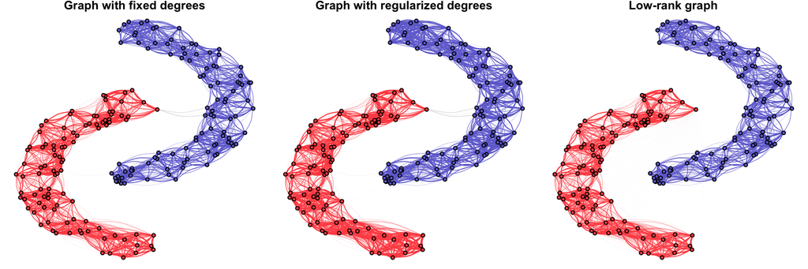

```r
library(spectralGraphTopology)

old_par <- par(mfcol = c(1, 3), mar = c(0, 0, 0.8, 0))   # b-l-t-r
plot_graph(W = W_smooth(data2moons$data, m = 20),
           layout = data2moons$data, clusters = data2moons$clusters,
           main = "Graph with fixed degrees")
plot_graph(W = W_kalofolias(X = data2moons$data, m = 20),
           layout = data2moons$data, clusters = data2moons$clusters,
           main = "Graph with regularized degrees")
plot_graph(W = cluster_k_component_graph(data2moons$data, k = 2, m = 20)$adjacency,
           layout = data2moons$data, clusters = data2moons$clusters,
           main = "Low-rank graph")
par(old_par)
```

[figure not shown]

Graphs learned based on smooth signals for the three-circle dataset.

```r
old_par <- par(mfcol = c(1, 3), mar = c(0, 0, 0.8, 0))   # b-l-t-r
plot_graph(W = W_smooth(data3circles$data, m = 20),
           layout = data3circles$data, clusters = data3circles$clusters,
           main = "Graph with fixed degrees")
plot_graph(W = W_kalofolias(X = data3circles$data, m = 20),
           layout = data3circles$data, clusters = data3circles$clusters,
           main = "Graph with regularized degrees")
plot_graph(W = cluster_k_component_graph(data3circles$data, k = 3, m = 20)$adjacency,
           layout = data3circles$data, clusters = data3circles$clusters,
           main = "Low-rank graph")
par(old_par)
```

# Learning graphs from Gaussian graphical model networks

We start with learning the Laplacian matrix `\bm{L}` for the following graphs:

- directly from the precision matrix
- sparse precision matrix from the *graphical lasso* (GLASSO) (Banerjee et al., 2008; Friedman et al., 2008)
  $$\begin{array}{ll}
  \underset{\bm{\Theta}\succ\bm{0}}{\textm{maximize}}
  & \textm{log det}(\bm{\Theta}) - \textm{Tr}(\bm{\Theta}\bm{S}) - \rho\|\bm{\Theta}\|_{1,\textm{off}},
  \end{array}$$
- the Laplacian-structured GLASSO (Egilmez et al., 2017; Lake and Tenenbaum, 2010; Zhao et al., 2019), which is implemented in the package [`spectralGraphTopology`](https://github.com/mirca/spectralGraphTopology)
  $$\begin{array}{ll}
  \underset{\bm{L}\succeq\bm{0}}{\textm{maximize}}
  & \textm{log gdet}(\bm{L}) - \textm{Tr}(\bm{L}\bm{S}) - \rho\|\bm{L}\|_{1,\textm{off}}\\
  \textm{subject to}
  & \bm{L}\bm{1}=\bm{0}, \quad L_{ij} = L_{ji} \le 0, \quad \forall i\neq j,
  \end{array}$$

```r
L_precision <- function(S, threshold = 0) {
  L <- ginv(S)
  diag_L <- diag(L)  # safe diagonal elements
  L <- ifelse(abs(L) <= threshold*mean(diag_L), 0, L)
  diag(L) <- diag_L  # recover diagonal elements
  return(L)
}


L_GLASSO <- function(S, rho = 1e-5) {
  L <- glasso::glasso(S, rho)$wi
  colnames(L) <- rownames(L) <- rownames(S)
  return(L)
}
```

Graphs learned based on Gaussian graphical models for the two-moon dataset:

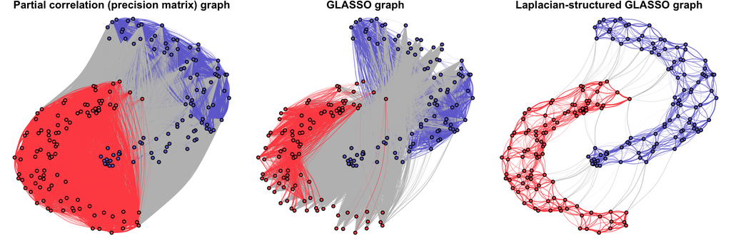

```r
old_par <- par(mfcol = c(1, 3), mar = c(0, 0, 0.8, 0))   # b-l-t-r
plot_graph(L = L_precision(S = data2moons$data %*% t(data2moons$data), threshold = 1e-2),
           layout = data2moons$data, clusters = data2moons$clusters,
           main = "Partial correlation (precision matrix) graph")
plot_graph(L = L_GLASSO(S = data2moons$data %*% t(data2moons$data), rho = 1e-4),
           layout = data2moons$data, clusters = data2moons$clusters,
           main = "GLASSO graph")
plot_graph(L = learn_laplacian_gle_admm(S = data2moons$data %*% t(data2moons$data), maxiter = 200)$laplacian,
           layout = data2moons$data, clusters = data2moons$clusters,
           main = "Laplacian-structured GLASSO graph")
par(old_par)
```

Graphs learned based on Gaussian graphical models for the three-circle dataset:

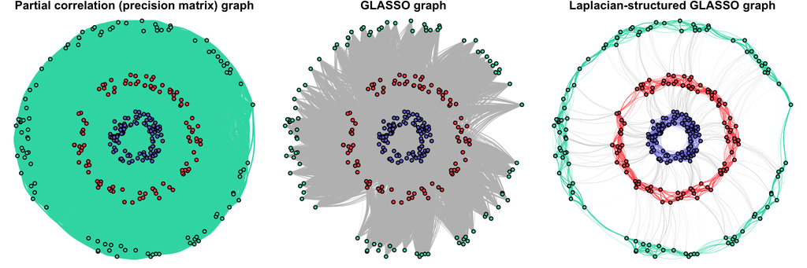

```r
old_par <- par(mfcol = c(1, 3), mar = c(0, 0, 0.8, 0))   # b-l-t-r
plot_graph(L = L_precision(S = data3circles$data %*% t(data3circles$data),  threshold = 1e-2),
           layout = data3circles$data, clusters = data3circles$clusters,
           main = "Partial correlation (precision matrix) graph")
plot_graph(L = L_GLASSO(S = data3circles$data %*% t(data3circles$data), rho = 1e-4),
           layout = data3circles$data, clusters = data3circles$clusters,
           main = "GLASSO graph")
plot_graph(L = learn_laplacian_gle_admm(S = data3circles$data %*% t(data3circles$data), maxiter = 200)$laplacian,
           layout = data3circles$data, clusters = data3circles$clusters,
           main = "Laplacian-structured GLASSO graph")
par(old_par)
```

# Learning $k$-component graphs

We learn $k$-component graphs based on:

- the smooth signal graph formulation (Nie et al., 2016):
  $$\begin{array}{ll}
  \underset{\bm{W}}{\textm{minimize}}
  & \textm{Tr}(\bm{W}\bm{Z}) + \gamma\|\bm{W}\|_\textm{F}^2\\
  \textm{subject to}
  & \textm{diag}(\bm{W})=\bm{0}, \quad \bm{W}=\bm{W}^\T \ge \bm{0}\\
  & \bm{W}\bm{1} = \bm{1}.
  \end{array}$$
- the same graph further approximated by a low-rank one (Nie et al., 2016):
  $$\begin{array}{ll}
  \underset{\bm{W}}{\textm{minimize}}
  & \|\bm{W} - \bm{W}_0\|_\textm{F}^2\\
  \textm{subject to}
  & \bm{W}\bm{1} = \bm{1}, \quad \textm{diag}(\bm{W})=\bm{0}, \quad \bm{W}=\bm{W}^\T \ge \bm{0}\\
  & \textm{rank}\left(\mathcal{L}(\bm{W})\right) = p - k,
  \end{array}$$
- the joint low-rank smooth signal graph formulation:
  $$\begin{array}{ll}
  \underset{\bm{L}\succeq\bm{0}, \bm{F}}{\textm{minimize}}
  & \textm{Tr}\left(\bm{X}\bm{L}\bm{X}^\T\right) + \frac{\gamma}{2}\|\bm{L}\|_\textm{F,off}^2 + \gamma \textm{Tr}\left(\bm{F}^\T\bm{L}\bm{F}\right)\\
  \textm{subject to}
  & \bm{L}\bm{1}=\bm{0}, \quad L_{ij} = L_{ji} \le 0, \quad \forall i\neq j\\
  & \textm{diag}(\bm{L})=\bm{1}\\
  & \bm{F}^\T\bm{F}=\bm{I}.
  \end{array}$$

Graphs learned based on smooth signals for the three-circle dataset:

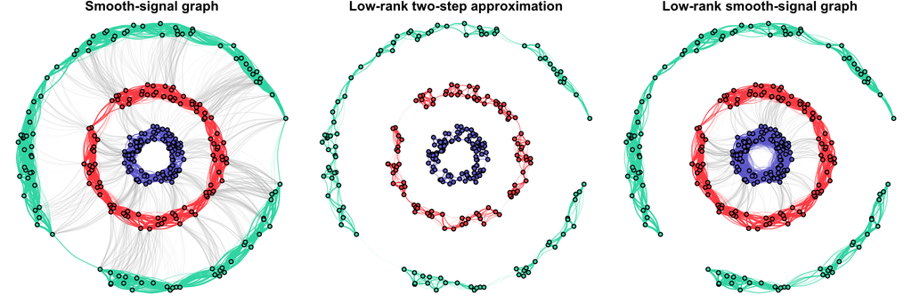

```r
library(spectralGraphTopology)

W_smooth_3circle <- W_smooth(data3circles$data)
W_approx_lowrank_3circle <- cluster_k_component_graph(data3circles$data, k = 3, m = 7)$adjacency
W_lowrank_3circle <- learn_k_component_graph(S = crossprod(t(data3circles$data)),
                                             k = 3,
                                             beta = 1,
                                             fix_beta = FALSE,
                                             verbose = TRUE,
                                             abstol = 1e-3)$adjacency


old_par <- par(mfcol = c(1, 3), mar = c(0, 0, 0.8, 0))   # b-l-t-r
plot_graph(W = W_smooth_3circle,
           layout = data3circles$data, clusters = data3circles$clusters,
           main = "Smooth-signal graph")
plot_graph(W = W_approx_lowrank_3circle,
           layout = data3circles$data, clusters = data3circles$clusters,
           main = "Low-rank two-step approximation")
plot_graph(W = W_lowrank_3circle,
           layout = data3circles$data, clusters = data3circles$clusters,
           main = "Low-rank smooth-signal graph")
par(old_par)
```

## References

Banerjee, O., El Ghaoui, L., and d’Aspremont, A. (2008). Model selection through sparse maximum likelihood estimation for multivariate Gaussian or binary data. *Journal of Machine Learning Research (JMLR)*, *9*, 485–516.

Egilmez, H. E., Pavez, E., and Ortega, A. (2017). Graph learning from data under Laplacian and structural constraints. *IEEE Journal of Selected Topics in Signal Processing*, *11*(6), 825–841.

Friedman, J., Hastie, T., and Tibshirani, R. (2008). Sparse inverse covariance estimation with the graphical lasso. *Biostatistics*, *9*(3), 432–441.

Kalofolias, V. (2016). How to learn a graph from smooth signals. In *Proceedings of the international conference on artificial intelligence and statistics (AISTATS)*, pages 920–929.

Nie, F., Wang, X., Jordan, M., and Huang, H. (2016). The constrained Laplacian rank algorithm for graph-based clustering. In *Proceedings of the AAAI conference on artificial intelligence*, pages 1969–1976. Phoenix, Arizona, USA.

Zhao, L., Wang, Y., Kumar, S., and Palomar, D. P. (2019). Optimization algorithms for graph Laplacian estimation via ADMM and MM. *IEEE Transactions on Signal Processing*, *67*(16), 4231–4244.